# Machine Learning Project

Jun 20th, 2015

## Summary

### reading of the source data and subset variables with meaningful values

```r
setwd("/Users/yangjin84/coursera/Practical_Machine_Learning")
download.file("https://d396qusza40orc.cloudfront.net/predmachlearn/pml-training.csv","training.csv","curl")
download.file("https://d396qusza40orc.cloudfront.net/predmachlearn/pml-testing.csv","testing.csv","curl")
trainingset <- read.csv("training.csv")
testingset <- read.csv("testing.csv")
trainingset1 <- subset(trainingset,select = c(user_name, roll_belt, pitch_belt, yaw_belt, total_accel_belt,gyros_belt_x, gyros_belt_y, gyros_belt_z, accel_belt_x, accel_belt_y, accel_belt_z, magnet_belt_x, magnet_belt_y, magnet_belt_z,roll_arm, pitch_arm, yaw_arm, total_accel_arm,gyros_arm_x, gyros_arm_y, gyros_arm_z, accel_arm_x, accel_arm_y, accel_arm_z, magnet_arm_x, magnet_arm_y, magnet_arm_z,roll_dumbbell, pitch_dumbbell, yaw_dumbbell, total_accel_dumbbell,gyros_dumbbell_x, gyros_dumbbell_y, gyros_dumbbell_z, accel_dumbbell_x, accel_dumbbell_y, accel_dumbbell_z, magnet_dumbbell_x, magnet_dumbbell_y, magnet_dumbbell_z, roll_forearm, pitch_forearm, yaw_forearm, total_accel_forearm,gyros_forearm_x, gyros_forearm_y, gyros_forearm_z, accel_forearm_x, accel_forearm_y, accel_forearm_z, magnet_forearm_x, magnet_forearm_y, magnet_forearm_z,classe))
trainingset_carlitos <- trainingset1[trainingset1$user_name == "carlitos",]
trainingset_pedro <- trainingset1[trainingset1$user_name == "pedro",]
trainingset_adelmo <- trainingset1[trainingset1$user_name == "adelmo",]
trainingset_charles <- trainingset1[trainingset1$user_name == "charles",]
trainingset_eurico <- trainingset1[trainingset1$user_name == "eurico",]
trainingset_jeremy <- trainingset1[trainingset1$user_name == "jeremy",]
testingset1 <- subset(testingset,select = c(user_name, roll_belt, pitch_belt, yaw_belt, total_accel_belt,gyros_belt_x, gyros_belt_y, gyros_belt_z, accel_belt_x, accel_belt_y, accel_belt_z, magnet_belt_x, magnet_belt_y, magnet_belt_z,roll_arm, pitch_arm, yaw_arm, total_accel_arm,gyros_arm_x, gyros_arm_y, gyros_arm_z, accel_arm_x, accel_arm_y, accel_arm_z, magnet_arm_x, magnet_arm_y, magnet_arm_z,roll_dumbbell, pitch_dumbbell, yaw_dumbbell, total_accel_dumbbell,gyros_dumbbell_x, gyros_dumbbell_y, gyros_dumbbell_z, accel_dumbbell_x, accel_dumbbell_y, accel_dumbbell_z, magnet_dumbbell_x, magnet_dumbbell_y, magnet_dumbbell_z, roll_forearm, pitch_forearm, yaw_forearm, total_accel_forearm,gyros_forearm_x, gyros_forearm_y, gyros_forearm_z, accel_forearm_x, accel_forearm_y, accel_forearm_z, magnet_forearm_x, magnet_forearm_y, magnet_forearm_z))
```

### Load package caret and conduct machine learning on the training dataset.

```r
library(ggplot2)
library(lattice)
library(caret)
library(rattle)
```

- Using caret package function “feaurePlot”, the relationship between each variable and the classe variable can be plotted. See below for an example.

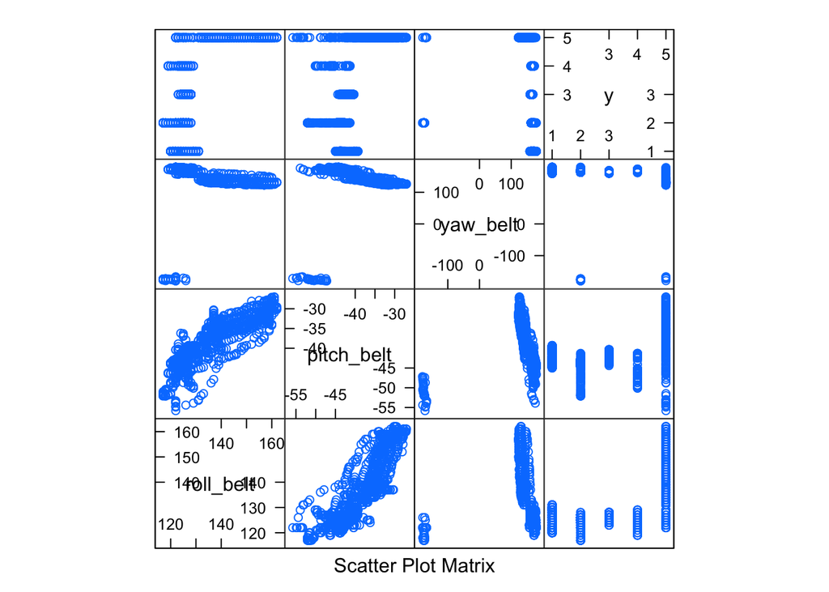

```r
trainingset_adelmo2 <- trainingset_adelmo
trainingset_adelmo2$classe <- as.numeric(trainingset_adelmo2$classe)
featurePlot(x = trainingset_adelmo2[,c("roll_belt","pitch_belt","yaw_belt")], y = trainingset_adelmo2$classe, plot = "pairs")
```

```r
adelmo <- subset(trainingset_adelmo,select = c(roll_belt, accel_belt_x, accel_belt_z, magnet_belt_z, roll_arm, pitch_arm, gyros_arm_z, accel_arm_y, total_accel_arm, magnet_belt_y, pitch_dumbbell, gyros_dumbbell_z, accel_belt_x, magnet_dumbbell_x, gyros_forearm_z, accel_forearm_z, total_accel_forearm, magnet_forearm_z,classe))
inTrain <- createDataPartition(y = adelmo$classe,p = 0.7,list = FALSE)
trainadelmo <- adelmo[inTrain,];testadelmo <- adelmo[-inTrain,]
modFit <- train(classe~., method = "rf",data = trainadelmo, prox=TRUE)
modFit
```

```
## Random Forest
##
## 2727 samples
##   18 predictor
##    5 classes: 'A', 'B', 'C', 'D', 'E'
##
## No pre-processing
## Resampling: Bootstrapped (25 reps)
##
## Summary of sample sizes: 2727, 2727, 2727, 2727, 2727, 2727, ...
##
## Resampling results across tuning parameters:
##
##   mtry  Accuracy   Kappa      Accuracy SD  Kappa SD
##    2    0.9699380  0.9616736  0.006538154  0.008282411
##   10    0.9721373  0.9644913  0.005525368  0.006985239
##   18    0.9595294  0.9484268  0.008806416  0.011156614
##
## Accuracy was used to select the optimal model using  the largest value.
## The final value used for the model was mtry = 10.
```

```r
testresult <- predict(modFit,newdata = testadelmo)
Totalfaulseprediction <- sum(testresult != testadelmo$classe)
total <- length(testadelmo$classe)
misclassificationrate <- Totalfaulseprediction/total
```

The misclassificationrate is quite small (0.0257511), so this method is valid. Same method was used for the rest of tainingdata. Due to the word limit and the time limit to run the random forest model, the process is omitted here. The detailed r program is stored in appendix.

```r
ans <-  rep(NA,20)
testingsetadelmo <- subset(testingset1,select = c(user_name, roll_belt, accel_belt_x, accel_belt_z, magnet_belt_z, roll_arm, pitch_arm, gyros_arm_z, accel_arm_y, total_accel_arm, magnet_belt_y, pitch_dumbbell, gyros_dumbbell_z, accel_belt_x, magnet_dumbbell_x, gyros_forearm_z, accel_forearm_z, total_accel_forearm, magnet_forearm_z))
for (i in 1:dim(testingsetadelmo)[1]){
  if (testingsetadelmo$user_name[i]== "adelmo"){
    ans[i] <- as.character(predict(modFit,newdata = testingsetadelmo[i,]))
  }
}
ans
```

```
##  [1] NA  NA  NA  "A" NA  NA  NA  NA  NA  NA  NA  NA  NA  NA  NA  NA  NA
## [18] NA  NA  NA
```

The same method was used for the rest of the data. Please see Appendix for detailed r program. The final answer is: [1] “B” “A” “B” “A” “A” “E” “D” “B” “A” “A” “B” “C” “B” “A” “E” “E” “A” “B” “B” “B”

### Appendix

– Training for user_name carlitos, charles, eurico, jeremy, and pedro: r code: carlitos <- subset(trainingset_carlitos,select = c(yaw_belt, accel_belt_x, accel_belt_z, magnet_belt_x, roll_arm, pitch_arm, accel_arm_z, total_accel_arm, magnet_arm_z, pitch_dumbbell, gyros_dumbbell_x, gyros_dumbbell_y, accel_dumbbell_x, accel_dumbbell_y,total_accel_dumbbell, magnet_dumbbell_z, roll_forearm, pitch_forearm, gyros_forearm_z, accel_forearm_x, total_accel_forearm, magnet_forearm_x, magnet_forearm_z,classe)) inTrain <- createDataPartition(y = carlitos$classe,p = 0.7,list = FALSE) traincarlitos <- carlitos[inTrain,];testcarlitos <- carlitos[-inTrain,] modFit2 <- train(classe~., method = "rf",data = traincarlitos, prox=TRUE) testresult <- predict(modFit,newdata = testcarlitos) Totalfaulseprediction <- sum(testresult != testcarlitos$classe) total <- length(testcarlitos$classe) misclassificationrate <- Totalfaulseprediction/total

charles <- subset(trainingset_charles,select = c(yaw_belt, accel_belt_x, accel_belt_z, magnet_belt_x, roll_arm, pitch_arm, accel_arm_z, total_accel_arm, magnet_arm_z, pitch_dumbbell, gyros_dumbbell_x, gyros_dumbbell_y, accel_dumbbell_x, accel_dumbbell_y,total_accel_dumbbell, magnet_dumbbell_z, roll_forearm, pitch_forearm, gyros_forearm_z, accel_forearm_x, total_accel_forearm, magnet_forearm_x, magnet_forearm_z,classe)) inTrain <- createDataPartition(y = charles$classe,p = 0.7,list = FALSE) traincharles <- charles[inTrain,];testcharles <- charles[-inTrain,] modFit3 <- train(classe~., method = "rf",data = traincharles, prox=TRUE) testresult <- predict(modFit,newdata = testcharles) Totalfaulseprediction <- sum(testresult != testcharles$classe) total <- length(testcharles$classe) misclassificationrate <- Totalfaulseprediction/total

eurico <- subset(trainingset_eurico,select = c(yaw_belt, accel_belt_x, accel_belt_z, magnet_belt_x, roll_arm, pitch_arm, accel_arm_z, total_accel_arm, magnet_arm_z, pitch_dumbbell, gyros_dumbbell_x, gyros_dumbbell_y, accel_dumbbell_x, accel_dumbbell_y,total_accel_dumbbell, magnet_dumbbell_z, roll_forearm, pitch_forearm, gyros_forearm_z, accel_forearm_x, total_accel_forearm, magnet_forearm_x, magnet_forearm_z,classe)) inTrain <- createDataPartition(y = eurico$classe,p = 0.7,list = FALSE) traineurico <- eurico[inTrain,];testeurico <- eurico[-inTrain,] modFit4 <- train(classe~., method = "rf",data = traineurico, prox=TRUE) testresult <- predict(modFit,newdata = testeurico) Totalfaulseprediction <- sum(testresult != testeurico$classe) total <- length(testeurico$classe) misclassificationrate <- Totalfaulseprediction/total

jeremy <- subset(trainingset_jeremy,select = c(yaw_belt, accel_belt_x, accel_belt_z, magnet_belt_x, roll_arm, pitch_arm, accel_arm_z, total_accel_arm, magnet_arm_z, pitch_dumbbell, gyros_dumbbell_x, gyros_dumbbell_y, accel_dumbbell_x, accel_dumbbell_y,total_accel_dumbbell, magnet_dumbbell_z, roll_forearm, pitch_forearm, gyros_forearm_z, accel_forearm_x, total_accel_forearm, magnet_forearm_x, magnet_forearm_z,classe)) inTrain <- createDataPartition(y = jeremy$classe,p = 0.7,list = FALSE) trainjeremy <- jeremy[inTrain,];testjeremy <- jeremy[-inTrain,] modFit5 <- train(classe~., method = "rf",data = trainjeremy, prox=TRUE) testresult <- predict(modFit,newdata = testjeremy) Totalfaulseprediction <- sum(testresult != testjeremy$classe) total <- length(testjeremy$classe) misclassificationrate <- Totalfaulseprediction/total

pedro <- subset(trainingset_pedro,select = c(yaw_belt, accel_belt_x, accel_belt_z, magnet_belt_x, roll_arm, pitch_arm, accel_arm_z, total_accel_arm, magnet_arm_z, pitch_dumbbell, gyros_dumbbell_x, gyros_dumbbell_y, accel_dumbbell_x, accel_dumbbell_y,total_accel_dumbbell, magnet_dumbbell_z, roll_forearm, pitch_forearm, gyros_forearm_z, accel_forearm_x, total_accel_forearm, magnet_forearm_x, magnet_forearm_z,classe)) inTrain <- createDataPartition(y = pedro$classe,p = 0.7,list = FALSE) trainpedro <- pedro[inTrain,];testpedro <- pedro[-inTrain,] modFit6 <- train(classe~., method = "rf",data = trainpedro, prox=TRUE) testresult <- predict(modFit,newdata = testpedro) Totalfaulseprediction <- sum(testresult != testpedro$classe) total <- length(testpedro$classe) misclassificationrate <- Totalfaulseprediction/total

– Prediction of testingset using the created modFiti model: r code: testingsetcarlitos <- subset(testingset1,select = c(user_name, yaw_belt, accel_belt_x, accel_belt_z, magnet_belt_x, roll_arm, pitch_arm, accel_arm_z, total_accel_arm, magnet_arm_z, pitch_dumbbell, gyros_dumbbell_x, gyros_dumbbell_y, accel_dumbbell_x, accel_dumbbell_y,total_accel_dumbbell, magnet_dumbbell_z, roll_forearm, pitch_forearm, gyros_forearm_z, accel_forearm_x, total_accel_forearm, magnet_forearm_x, magnet_forearm_z)) for (i in 1:dim(testingsetcarlitos)[1]){ if (testingsetcarlitos$user_name[i]== "carlitos"){ ans[i] <- as.character(predict(modFit2,newdata = testingsetcarlitos[i,])) } } for (i in 1:dim(testingsetcarlitos)[1]){ if (testingsetcarlitos$user_name[i]== “charles”){ ans[i] <- as.character(predict(modFit3,newdata = testingsetcarlitos[i,])) } } for (i in 1:dim(testingsetcarlitos)[1]){ if (testingsetcarlitos$user_name[i]== "eurico"){ ans[i] <- as.character(predict(modFit4,newdata = testingsetcarlitos[i,])) } } for (i in 1:dim(testingsetcarlitos)[1]){ if (testingsetcarlitos$user_name[i]== “jeremy”){ ans[i] <- as.character(predict(modFit5,newdata = testingsetcarlitos[i,])) } } for (i in 1:dim(testingsetcarlitos)[1]){ if (testingsetcarlitos$user_name[i]== “pedro”){ ans[i] <- as.character(predict(modFit6,newdata = testingsetcarlitos[i,])) } }